# 432 Study 1: Predicting Development and Time to Onset of Depression in Multiple Sclerosis Patients

## 0.1 Preliminaries

```r
library(arm)
library(leaps)
library(tableone)
library(pander)
library(ROCR)
library(skimr)
library(rms)
library(broom)
library(tidyverse)
```

# 1 Task 1: Data Source

The source of this cross-sectional data is the Accelerated Cure Project for Multiple Sclerosis, an open-access database of patients designed to study individuals with multiple sclerosis (MS). Subjects are recruited from ten centers across the United States and data are collected through a survey administered by the patient’s neurologist or trained staff.

Additional information about the data source and the nature of the non-profit organization responsible for collection and management of this data can be found at [https://www.acceleratedcure.org/].

# 2 Task 2: Load and Tidy the Data

```r
msdepression <- read.csv("msdepression.csv") %>% tbl_df
msdepression <- select(msdepression, ID, DEPRESSED_AFTER_ONSET, TIME_TO_DEPRESSION, SMOKER_5YR_B4_ONSET, BMI_AT_ONSET, HLA_DRB1_1501, VD_AT_ONSET, EDUCATION_YEARS, DEP_FAMILYHX, NUMBER_IMPAIRED_DOMAINS_AT_ONSET)
colSums(is.na(msdepression))
```

```
                              ID            DEPRESSED_AFTER_ONSET
                               0                                0
              TIME_TO_DEPRESSION              SMOKER_5YR_B4_ONSET
                             796                                4
                    BMI_AT_ONSET                    HLA_DRB1_1501
                               3                              206
                     VD_AT_ONSET                  EDUCATION_YEARS
                               8                                1
                    DEP_FAMILYHX NUMBER_IMPAIRED_DOMAINS_AT_ONSET
                               0                                3
```

For this step, I loaded in the csv dataset and selected the variables of interest. Last, I took a look at the number of missing variables across the observations. Luckily there is no missing data in my binary outcome of having depression after onset. My second continuous outcome seems to have missing variables. However, it is not truly missing data because the ones coded as NAs are merely the individuals who did not have depression after onset (and thus do not have a time to depression). For the actual linear regression, I will only be using the observations where depressed_after_onset is not equal to zero (n = 195). I left the rest of the missing observations in the predictor variables for the next (imputation step) part of the study.

Looking at the distribution of the data, especially the categorical variables, I decided to collapse a few of the categories of VD_AT_ONSET since the higher categories of the variable were sparse.

```r
Hmisc::describe(msdepression$VD_AT_ONSET)
```

```
msdepression$VD_AT_ONSET
       n  missing distinct     Info     Mean      Gmd
     982        8        5    0.476   0.2424   0.4055

Value          0     1     2     3     4
Frequency    790   153    33     5     1
Proportion 0.804 0.156 0.034 0.005 0.001
```

```r
msdepression$VD_AT_ONSET <- cut(msdepression$VD_AT_ONSET, breaks=c(-1,0,1, 5), labels =c("0", "1", "2"))
Hmisc::describe(msdepression$VD_AT_ONSET)
```

```
msdepression$VD_AT_ONSET
       n  missing distinct
     982        8        3

Value          0     1     2
Frequency    790   153    39
Proportion 0.804 0.156 0.040
```

# 3 Task 3: Listing of My Tibble

```r
msdepression
```

```
# A tibble: 990 x 10
       ID DEPRESSED_AFTER_ONSET TIME_TO_DEPRESSION SMOKER_5YR_B4_ONSET
   <fctr>                 <int>              <int>               <int>
 1   1-10                     0                 NA                   0
 2  1-100                     0                 NA                   0
 3  1-103                     0                 NA                   0
 4  1-105                     0                 NA                   0
 5  1-108                     0                 NA                   1
 6  1-109                     0                 NA                   0
 7  1-110                     0                 NA                   1
 8  1-111                     0                 NA                   0
 9  1-115                     0                 NA                   0
10  1-116                     1                 11                   0
# ... with 980 more rows, and 6 more variables: BMI_AT_ONSET <int>,
#   HLA_DRB1_1501 <int>, VD_AT_ONSET <fctr>, EDUCATION_YEARS <int>,
#   DEP_FAMILYHX <int>, NUMBER_IMPAIRED_DOMAINS_AT_ONSET <int>
```

```r
str(msdepression)
```

```
Classes 'tbl_df', 'tbl' and 'data.frame':   990 obs. of  10 variables:
 $ ID                              : Factor w/ 990 levels "1-10","1-100",..: 1 2 3 4 5 6 7 8 9 10 ...
 $ DEPRESSED_AFTER_ONSET           : int  0 0 0 0 0 0 0 0 0 1 ...
 $ TIME_TO_DEPRESSION              : int  NA NA NA NA NA NA NA NA NA 11 ...
 $ SMOKER_5YR_B4_ONSET             : int  0 0 0 0 1 0 1 0 0 0 ...
 $ BMI_AT_ONSET                    : int  0 0 0 0 0 0 0 0 0 0 ...
 $ HLA_DRB1_1501                   : int  NA NA 1 NA NA NA NA 1 NA NA ...
 $ VD_AT_ONSET                     : Factor w/ 3 levels "0","1","2": 1 1 1 2 1 1 1 1 1 1 ...
 $ EDUCATION_YEARS                 : int  17 14 16 16 18 16 13 20 16 12 ...
 $ DEP_FAMILYHX                    : int  1 1 0 1 1 0 0 1 1 1 ...
 $ NUMBER_IMPAIRED_DOMAINS_AT_ONSET: int  3 2 2 6 3 1 2 1 4 1 ...
```

In this tibble of the dataset, there are 990 observations (subjects) and 9 variables.

# 4 Task 4: Code Book

[output not shown]

# 5 Task 5: My Subjects

This is a cross-sectional study of 990 Americans diagnosed with multiple sclerosis (onset at greater than 18 years of age) recruited from ten centers across the United States.

# 6 Task 6: My Variables

The variables of this data set are:

- ID - This is a unique subject identification code in the format of ##-###.
- DEPRESSED_AFTER_ONSET - This is a binary indicator of whether the subject had developed depression after onset of multiple sclerosis (0 = No, 1 = Yes).
- TIME_TO_DEPRESSION - This is the time to depression if the subject developed depression after onset of MS. This variable is expressed in years.
- SMOKER_5YR_B4_ONSET - This is a binary indicator variable of whether the subject had a smoking history within five years of MS onset (0 = No, 1 = Yes).
- BMI_AT_ONSET - This variable is a indicator marker whether the patient has had a diagnosis of obesity by a physician at/before the time of MS onset (0 = No, 1 = Yes).
- HLA_DRB1_1501 - This is multi-level categorical variable indicating the number of MS genetic risk alleles present, specifically the number of positive HLA-DRB1 risk variant alleles in the subject (0-2 alleles present).
- VD_AT_ONSET - This is a multi-level ordinal categorical variable indicating number of vascular disease in the subject. Vascular disease included in this count were presence of hypercholesterolemia, chronic obstructive pulmonary disease (COPD), obesity, high blood pressure, heart disease, and type two diabetes (range of 0-2 vascular disease present where 0=no VD, 1=one VD, and 2=two or more VD).
- EDUCATION_YEARS - This is a continuous variable indicating number of years of education.
- DEP_FAMILYHX - This is a binary variable indicating presence or absence of family history of depression (0 = No, 1 = Yes).
- NUMBER_IMPAIRED_DOMAINS_AT_ONSET - This number of impaired domains variable is classified as quantitative due to the >10 levels present and ordinal nature. This variable describes the number of impaired domains for subjects at onset of MS out of motor, cerebellar, spasticity, optic nerve, facial motor, facial sensory, sensory, brain stem bulbar, cognitive, sexual, bladder/bowel, affect mood, and fatigue (range of 0 - 12).

# 7 Task 7: My Planned Linear Regression Model

The proposed quantitative outcome variable is time to depression of the subset of patients who have depression after developing the disease after onset of multiple sclerosis (n=195 out of the total 990 subjects). The prediction variables I plan to consider for the linear regression model are:

- HLA_DRB1 alleles
- Obesity
- 5 year smoking status
- Years of education
- Vascular disease
- Family history of depression
- Number of impaired domains at onset of depression

# 8 Task 8: My Planned Logistic Regression Model

The proposed binary outcome variable is development of depression after onset of multiple sclerosis (n=990). The prediction variables I plan to consider for the logistic regression model are:

- HLA_DRB1 alleles
- Obesity
- 5 year smoking status
- Years of education
- Vascular disease
- Family history of depression
- Number of impaired domains at onset of depression

# 9 Task 9: Affirmation

I can affirm that the data set meets all of the requirements specified in Dr. Love’s project instruction. The data set contains 990 observations which is within the limit of 100-1000 subjects. The nine variables include multi categorical, binary, and quantitative predictors along with each a proposed quantitative and binary outcome variable.

Additionally, I am certain that it is completely appropriate for these data to be shared with anyone, without any conditions. There are no concerns about privacy or security.

# 10 Linear Regression

## 10.1 Imputing Missing Values

```r
sapply(msdepression, class)
```

```
                              ID            DEPRESSED_AFTER_ONSET
                        "factor"                        "integer"
              TIME_TO_DEPRESSION              SMOKER_5YR_B4_ONSET
                       "integer"                        "integer"
                    BMI_AT_ONSET                    HLA_DRB1_1501
                       "integer"                        "integer"
                     VD_AT_ONSET                  EDUCATION_YEARS
                        "factor"                        "integer"
                    DEP_FAMILYHX NUMBER_IMPAIRED_DOMAINS_AT_ONSET
                       "integer"                        "integer"
```

```r
msdepression$DEPRESSED_AFTER_ONSET<-as.factor(msdepression$DEPRESSED_AFTER_ONSET)
msdepression$SMOKER_5YR_B4_ONSET<-as.factor(msdepression$SMOKER_5YR_B4_ONSET)
msdepression$HLA_DRB1_1501<-as.factor(msdepression$HLA_DRB1_1501)
msdepression$DEP_FAMILYHX<-as.factor(msdepression$DEP_FAMILYHX)
```

```r
sapply(msdepression, class)
```

```
                              ID            DEPRESSED_AFTER_ONSET
                        "factor"                         "factor"
              TIME_TO_DEPRESSION              SMOKER_5YR_B4_ONSET
                       "integer"                         "factor"
                    BMI_AT_ONSET                    HLA_DRB1_1501
                       "integer"                         "factor"
                     VD_AT_ONSET                  EDUCATION_YEARS
                        "factor"                        "integer"
                    DEP_FAMILYHX NUMBER_IMPAIRED_DOMAINS_AT_ONSET
                        "factor"                        "integer"
```

```r
mslin<-filter(msdepression, !is.na(msdepression$TIME_TO_DEPRESSION))
colSums(is.na(mslin))
```

```
                              ID            DEPRESSED_AFTER_ONSET
                               0                                0
              TIME_TO_DEPRESSION              SMOKER_5YR_B4_ONSET
                               0                                0
                    BMI_AT_ONSET                    HLA_DRB1_1501
                               1                               43
                     VD_AT_ONSET                  EDUCATION_YEARS
                               1                                0
                    DEP_FAMILYHX NUMBER_IMPAIRED_DOMAINS_AT_ONSET
                               0                                0
```

```r
Hmisc::describe(mslin$TIME_TO_DEPRESSION)
```

```
mslin$TIME_TO_DEPRESSION
       n  missing distinct     Info     Mean      Gmd      .05      .10
     194        0       35    0.995    10.09    9.459      1.0      1.0
     .25      .50      .75      .90      .95
     3.0      7.0     15.0     23.7     27.7

lowest :  1  2  3  4  5, highest: 33 34 35 38 44
```

```r
set.seed(123)
mslinim <- aregImpute(~ TIME_TO_DEPRESSION + BMI_AT_ONSET + as.factor(HLA_DRB1_1501) + VD_AT_ONSET,
                  data = mslin,
                  n.impute = 20,
                  pr = FALSE, x = TRUE)
mslinim
```

```
Multiple Imputation using Bootstrap and PMM

aregImpute(formula = ~TIME_TO_DEPRESSION + BMI_AT_ONSET + as.factor(HLA_DRB1_1501) +
    VD_AT_ONSET, data = mslin, n.impute = 20, x = TRUE, pr = FALSE)

n: 194  p: 4    Imputations: 20     nk: 3

Number of NAs:
TIME_TO_DEPRESSION       BMI_AT_ONSET      HLA_DRB1_1501
                 0                  1                 43
       VD_AT_ONSET
                 1

                   type d.f.
TIME_TO_DEPRESSION    s    2
BMI_AT_ONSET          l    1
HLA_DRB1_1501         c    2
VD_AT_ONSET           c    2

Transformation of Target Variables Forced to be Linear

R-squares for Predicting Non-Missing Values for Each Variable
Using Last Imputations of Predictors
 BMI_AT_ONSET HLA_DRB1_1501   VD_AT_ONSET
        0.210         0.073         0.306
```

```r
names(mslin)
```

```
 [1] "ID"                               "DEPRESSED_AFTER_ONSET"
 [3] "TIME_TO_DEPRESSION"               "SMOKER_5YR_B4_ONSET"
 [5] "BMI_AT_ONSET"                     "HLA_DRB1_1501"
 [7] "VD_AT_ONSET"                      "EDUCATION_YEARS"
 [9] "DEP_FAMILYHX"                     "NUMBER_IMPAIRED_DOMAINS_AT_ONSET"
```

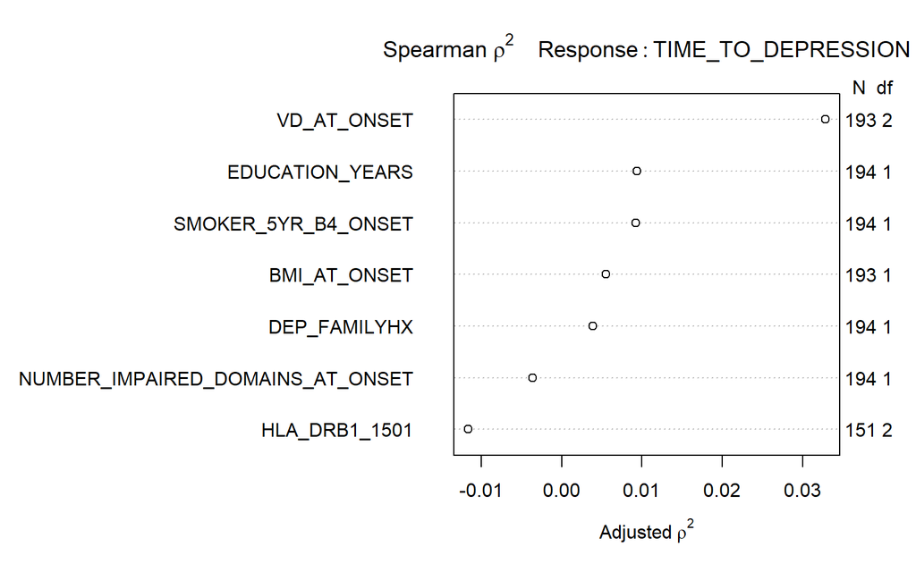

```r
plot(spearman2(TIME_TO_DEPRESSION ~ SMOKER_5YR_B4_ONSET + BMI_AT_ONSET + HLA_DRB1_1501 + VD_AT_ONSET + EDUCATION_YEARS + DEP_FAMILYHX + NUMBER_IMPAIRED_DOMAINS_AT_ONSET, data = mslin))
```

```r
mslinim.A <- fit.mult.impute(TIME_TO_DEPRESSION ~ SMOKER_5YR_B4_ONSET + BMI_AT_ONSET + HLA_DRB1_1501 + VD_AT_ONSET + EDUCATION_YEARS + DEP_FAMILYHX + NUMBER_IMPAIRED_DOMAINS_AT_ONSET, ols, mslinim, data = mslin)
```

```
Variance Inflation Factors Due to Imputation:

                       Intercept            SMOKER_5YR_B4_ONSET=1
                            1.00                             1.00
                    BMI_AT_ONSET                  HLA_DRB1_1501=1
                            1.00                             1.29
                 HLA_DRB1_1501=2                    VD_AT_ONSET=1
                            1.13                             1.01
                   VD_AT_ONSET=2                  EDUCATION_YEARS
                            1.00                             1.01
                  DEP_FAMILYHX=1 NUMBER_IMPAIRED_DOMAINS_AT_ONSET
                            1.01                             1.00

Rate of Missing Information:

                       Intercept            SMOKER_5YR_B4_ONSET=1
                            0.00                             0.00
                    BMI_AT_ONSET                  HLA_DRB1_1501=1
                            0.00                             0.22
                 HLA_DRB1_1501=2                    VD_AT_ONSET=1
                            0.12                             0.01
                   VD_AT_ONSET=2                  EDUCATION_YEARS
                            0.00                             0.01
                  DEP_FAMILYHX=1 NUMBER_IMPAIRED_DOMAINS_AT_ONSET
                            0.01                             0.00

d.f. for t-distribution for Tests of Single Coefficients:

                       Intercept            SMOKER_5YR_B4_ONSET=1
                      2061357.10                       2853587.79
                    BMI_AT_ONSET                  HLA_DRB1_1501=1
                      1142898.95                           379.08
                 HLA_DRB1_1501=2                    VD_AT_ONSET=1
                         1371.21                        300289.77
                   VD_AT_ONSET=2                  EDUCATION_YEARS
                      1227704.50                        639474.10
                  DEP_FAMILYHX=1 NUMBER_IMPAIRED_DOMAINS_AT_ONSET
                       207042.59                       1183929.96

The following fit components were averaged over the 20 model fits:

  fitted.values stats linear.predictors
```

```r
mslinim.A
```

```
Linear Regression Model

 fit.mult.impute(formula = TIME_TO_DEPRESSION ~ SMOKER_5YR_B4_ONSET +
     BMI_AT_ONSET + HLA_DRB1_1501 + VD_AT_ONSET + EDUCATION_YEARS +
     DEP_FAMILYHX + NUMBER_IMPAIRED_DOMAINS_AT_ONSET, fitter = ols,
     xtrans = mslinim, data = mslin)

                Model Likelihood     Discrimination
                   Ratio Test           Indexes
 Obs     194    LR chi2     16.92    R2       0.084
 sigma8.6992    d.f.            9    R2 adj   0.039
 d.f.    184    Pr(> chi2) 0.0499    g        2.919

 Residuals

     Min      1Q  Median      3Q     Max
 -13.916  -5.851  -1.683   4.787  32.099


                                  Coef    S.E.   t     Pr(>|t|)
 Intercept                         6.5010 4.0826  1.59 0.1130
 SMOKER_5YR_B4_ONSET=1             1.8749 1.2961  1.45 0.1497
 BMI_AT_ONSET                      2.4567 2.6977  0.91 0.3637
 HLA_DRB1_1501=1                   1.1431 1.5774  0.72 0.4696
 HLA_DRB1_1501=2                  -0.7699 2.7162 -0.28 0.7772
 VD_AT_ONSET=1                    -4.4198 1.7114 -2.58 0.0106
 VD_AT_ONSET=2                    -6.6123 3.2088 -2.06 0.0407
 EDUCATION_YEARS                   0.3117 0.2412  1.29 0.1979
 DEP_FAMILYHX=1                   -2.1264 1.2926 -1.65 0.1017
 NUMBER_IMPAIRED_DOMAINS_AT_ONSET -0.0791 0.2513 -0.31 0.7532
```

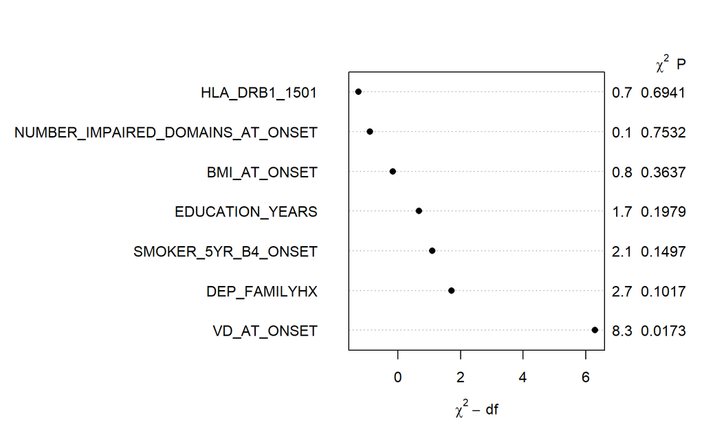

```r
plot(anova(mslinim.A))
```

```r
mb <- select(mslin, ID, DEPRESSED_AFTER_ONSET, TIME_TO_DEPRESSION, SMOKER_5YR_B4_ONSET, BMI_AT_ONSET, VD_AT_ONSET, EDUCATION_YEARS, DEP_FAMILYHX, NUMBER_IMPAIRED_DOMAINS_AT_ONSET)

mb<-na.omit(mb)
preds <- with(mb, cbind(SMOKER_5YR_B4_ONSET, BMI_AT_ONSET, VD_AT_ONSET, EDUCATION_YEARS, DEP_FAMILYHX, NUMBER_IMPAIRED_DOMAINS_AT_ONSET))

#for some reason i think the select function interferes with the regsubsets-it is not working now on a previous assignment that ran before
#x1 <- regsubsets(preds, y=mb)
#rs <- summary(x1)
#rs
```

# 11 Logistic Regression

Once again, here are the variables with missing observations:

```r
colSums(is.na(msdepression))
```

```
                              ID            DEPRESSED_AFTER_ONSET
                               0                                0
              TIME_TO_DEPRESSION              SMOKER_5YR_B4_ONSET
                             796                                4
                    BMI_AT_ONSET                    HLA_DRB1_1501
                               3                              206
                     VD_AT_ONSET                  EDUCATION_YEARS
                               8                                1
                    DEP_FAMILYHX NUMBER_IMPAIRED_DOMAINS_AT_ONSET
                               0                                3
```

```r
m.1 <- lrm(DEPRESSED_AFTER_ONSET ~ SMOKER_5YR_B4_ONSET + BMI_AT_ONSET + HLA_DRB1_1501 + VD_AT_ONSET + EDUCATION_YEARS + DEP_FAMILYHX + NUMBER_IMPAIRED_DOMAINS_AT_ONSET, data = msdepression, x = T, y = T)
m.1
```

```
Frequencies of Missing Values Due to Each Variable
           DEPRESSED_AFTER_ONSET              SMOKER_5YR_B4_ONSET
                               0                                4
                    BMI_AT_ONSET                    HLA_DRB1_1501
                               3                              206
                     VD_AT_ONSET                  EDUCATION_YEARS
                               8                                1
                    DEP_FAMILYHX NUMBER_IMPAIRED_DOMAINS_AT_ONSET
                               0                                3

Logistic Regression Model

 lrm(formula = DEPRESSED_AFTER_ONSET ~ SMOKER_5YR_B4_ONSET + BMI_AT_ONSET +
     HLA_DRB1_1501 + VD_AT_ONSET + EDUCATION_YEARS + DEP_FAMILYHX +
     NUMBER_IMPAIRED_DOMAINS_AT_ONSET, data = msdepression, x = T,
     y = T)


                      Model Likelihood     Discrimination    Rank Discrim.
                         Ratio Test           Indexes           Indexes
 Obs           772    LR chi2     25.14    R2       0.051    C       0.629
  0            621    d.f.            9    g        0.514    Dxy     0.258
  1            151    Pr(> chi2) 0.0028    gr       1.672    gamma   0.260
 max |deriv| 2e-10                         gp       0.080    tau-a   0.081
                                           Brier    0.153

                                  Coef    S.E.   Wald Z Pr(>|Z|)
 Intercept                        -1.5925 0.5988 -2.66  0.0078
 SMOKER_5YR_B4_ONSET=1             0.6428 0.1922  3.34  0.0008
 BMI_AT_ONSET                      0.2347 0.4140  0.57  0.5708
 HLA_DRB1_1501=1                  -0.0598 0.1952 -0.31  0.7593
 HLA_DRB1_1501=2                   0.4504 0.3627  1.24  0.2144
 VD_AT_ONSET=1                     0.3240 0.2637  1.23  0.2193
 VD_AT_ONSET=2                     0.3173 0.4688  0.68  0.4986
 EDUCATION_YEARS                  -0.0255 0.0348 -0.73  0.4645
 DEP_FAMILYHX=1                    0.5225 0.1869  2.80  0.0052
 NUMBER_IMPAIRED_DOMAINS_AT_ONSET  0.0003 0.0381  0.01  0.9942
```

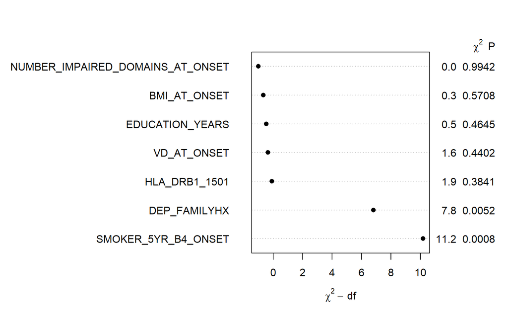

```r
plot(anova(m.1))
```

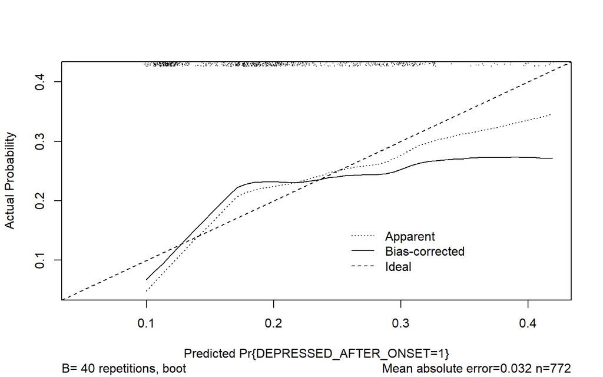

```
n=772   Mean absolute error=0.032   Mean squared error=0.00152
0.9 Quantile of absolute error=0.051
```

```r
plot(calibrate(m.1))
```

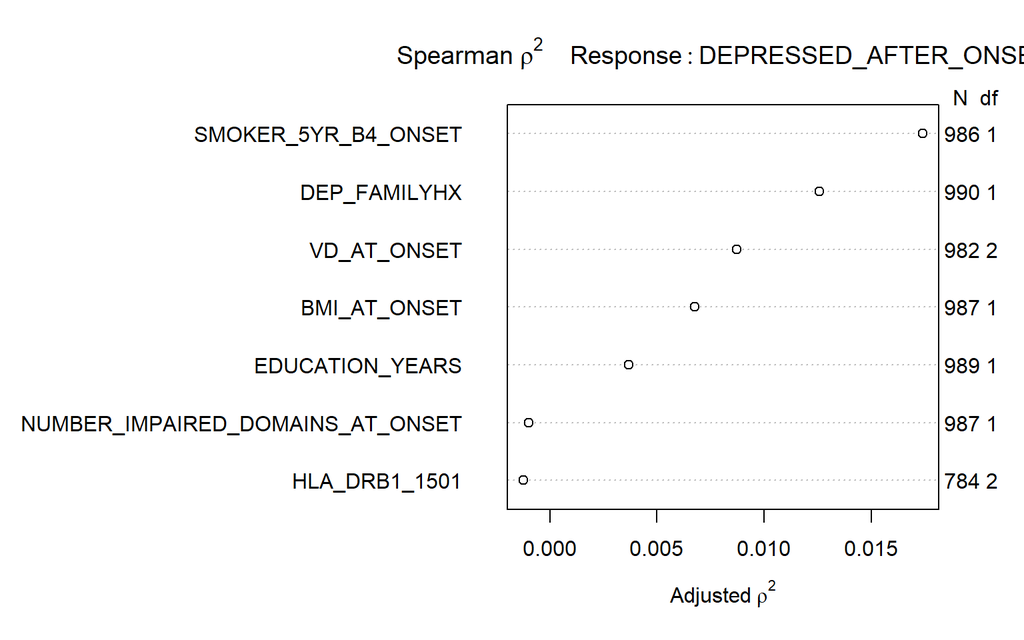

```r
plot(spearman2(DEPRESSED_AFTER_ONSET ~ SMOKER_5YR_B4_ONSET + BMI_AT_ONSET + HLA_DRB1_1501 + VD_AT_ONSET + EDUCATION_YEARS + DEP_FAMILYHX + NUMBER_IMPAIRED_DOMAINS_AT_ONSET, data = msdepression))
```

```r
m.2 <- lrm(DEPRESSED_AFTER_ONSET ~ SMOKER_5YR_B4_ONSET + BMI_AT_ONSET + VD_AT_ONSET + EDUCATION_YEARS + DEP_FAMILYHX, data = msdepression, x = T, y = T)
m.2
```

```
Frequencies of Missing Values Due to Each Variable
DEPRESSED_AFTER_ONSET   SMOKER_5YR_B4_ONSET          BMI_AT_ONSET
                    0                     4                     3
          VD_AT_ONSET       EDUCATION_YEARS          DEP_FAMILYHX
                    8                     1                     0

Logistic Regression Model

 lrm(formula = DEPRESSED_AFTER_ONSET ~ SMOKER_5YR_B4_ONSET + BMI_AT_ONSET +
     VD_AT_ONSET + EDUCATION_YEARS + DEP_FAMILYHX, data = msdepression,
     x = T, y = T)


                       Model Likelihood     Discrimination    Rank Discrim.
                          Ratio Test           Indexes           Indexes
 Obs           978    LR chi2      41.15    R2       0.065    C       0.650
  0            784    d.f.             6    g        0.575    Dxy     0.300
  1            194    Pr(> chi2) <0.0001    gr       1.777    gamma   0.307
 max |deriv| 1e-09                          gp       0.091    tau-a   0.096
                                            Brier    0.153

                       Coef    S.E.   Wald Z Pr(>|Z|)
 Intercept             -1.3865 0.5083 -2.73  0.0064
 SMOKER_5YR_B4_ONSET=1  0.6372 0.1692  3.77  0.0002
 BMI_AT_ONSET           0.4159 0.3626  1.15  0.2514
 VD_AT_ONSET=1          0.4382 0.2297  1.91  0.0564
 VD_AT_ONSET=2          0.4021 0.4182  0.96  0.3363
 EDUCATION_YEARS       -0.0415 0.0307 -1.35  0.1764
 DEP_FAMILYHX=1         0.5722 0.1655  3.46  0.0005
```

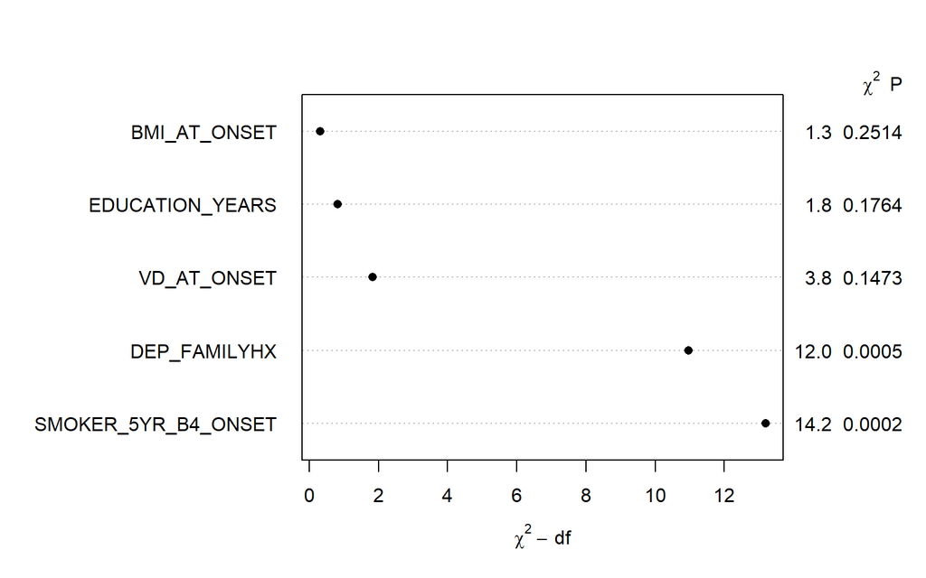

```r
plot(anova(m.2))
```

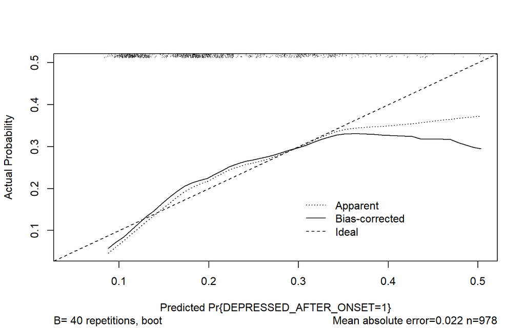

```
n=978   Mean absolute error=0.022   Mean squared error=9e-04
0.9 Quantile of absolute error=0.032
```

```r
plot(calibrate(m.2))
```

```r
m.3 <- lrm(DEPRESSED_AFTER_ONSET ~ SMOKER_5YR_B4_ONSET+ DEP_FAMILYHX + VD_AT_ONSET + EDUCATION_YEARS , data = msdepression, x = T, y = T)
m.3
```

```
Frequencies of Missing Values Due to Each Variable
DEPRESSED_AFTER_ONSET   SMOKER_5YR_B4_ONSET          DEP_FAMILYHX
                    0                     4                     0
          VD_AT_ONSET       EDUCATION_YEARS
                    8                     1

Logistic Regression Model

 lrm(formula = DEPRESSED_AFTER_ONSET ~ SMOKER_5YR_B4_ONSET + DEP_FAMILYHX +
     VD_AT_ONSET + EDUCATION_YEARS, data = msdepression, x = T,
     y = T)


                       Model Likelihood     Discrimination    Rank Discrim.
                          Ratio Test           Indexes           Indexes
 Obs           978    LR chi2      39.85    R2       0.063    C       0.644
  0            784    d.f.             5    g        0.568    Dxy     0.289
  1            194    Pr(> chi2) <0.0001    gr       1.764    gamma   0.296
 max |deriv| 1e-09                          gp       0.089    tau-a   0.092
                                            Brier    0.153

                       Coef    S.E.   Wald Z Pr(>|Z|)
 Intercept             -1.4136 0.5084 -2.78  0.0054
 SMOKER_5YR_B4_ONSET=1  0.6274 0.1688  3.72  0.0002
 DEP_FAMILYHX=1         0.5922 0.1644  3.60  0.0003
 VD_AT_ONSET=1          0.5453 0.2069  2.64  0.0084
 VD_AT_ONSET=2          0.6080 0.3739  1.63  0.1039
 EDUCATION_YEARS       -0.0401 0.0307 -1.31  0.1910
```

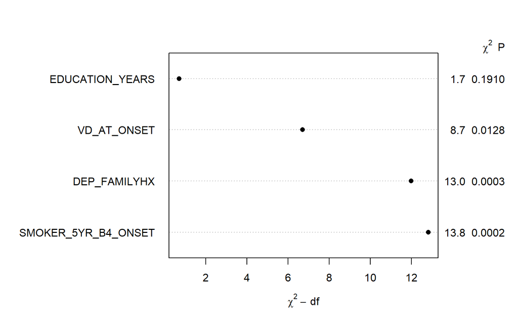

```r
plot(anova(m.3))
```

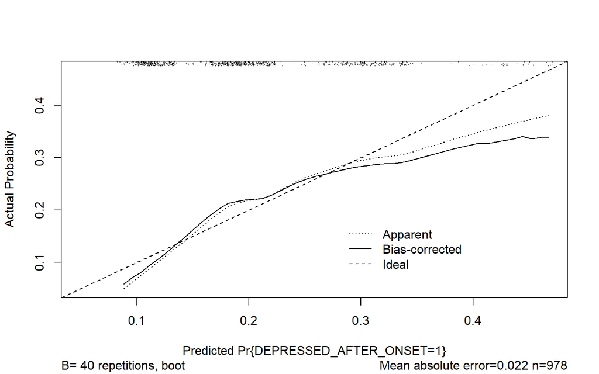

```
n=978   Mean absolute error=0.022   Mean squared error=0.00081
0.9 Quantile of absolute error=0.031
```

```r
plot(calibrate(m.3))
```

```r
f.3 <- aregImpute(~DEPRESSED_AFTER_ONSET + SMOKER_5YR_B4_ONSET + BMI_AT_ONSET + HLA_DRB1_1501 + VD_AT_ONSET + EDUCATION_YEARS + DEP_FAMILYHX + NUMBER_IMPAIRED_DOMAINS_AT_ONSET, n.impute = 20, data = msdepression, pr = FALSE, x = TRUE)
f.3
```

```
Multiple Imputation using Bootstrap and PMM

aregImpute(formula = ~DEPRESSED_AFTER_ONSET + SMOKER_5YR_B4_ONSET +
    BMI_AT_ONSET + HLA_DRB1_1501 + VD_AT_ONSET + EDUCATION_YEARS +
    DEP_FAMILYHX + NUMBER_IMPAIRED_DOMAINS_AT_ONSET, data = msdepression,
    n.impute = 20, x = TRUE, pr = FALSE)

n: 990  p: 8    Imputations: 20     nk: 3

Number of NAs:
           DEPRESSED_AFTER_ONSET              SMOKER_5YR_B4_ONSET
                               0                                4
                    BMI_AT_ONSET                    HLA_DRB1_1501
                               3                              206
                     VD_AT_ONSET                  EDUCATION_YEARS
                               8                                1
                    DEP_FAMILYHX NUMBER_IMPAIRED_DOMAINS_AT_ONSET
                               0                                3

                                 type d.f.
DEPRESSED_AFTER_ONSET               c    1
SMOKER_5YR_B4_ONSET                 c    1
BMI_AT_ONSET                        l    1
HLA_DRB1_1501                       c    2
VD_AT_ONSET                         c    2
EDUCATION_YEARS                     s    2
DEP_FAMILYHX                        c    1
NUMBER_IMPAIRED_DOMAINS_AT_ONSET    s    1

Transformation of Target Variables Forced to be Linear

R-squares for Predicting Non-Missing Values for Each Variable
Using Last Imputations of Predictors
             SMOKER_5YR_B4_ONSET                     BMI_AT_ONSET
                           0.082                            0.247
                   HLA_DRB1_1501                      VD_AT_ONSET
                           0.027                            0.293
                 EDUCATION_YEARS NUMBER_IMPAIRED_DOMAINS_AT_ONSET
                           0.066                            0.028
```

```r
fmi.m.3 <- fit.mult.impute(DEPRESSED_AFTER_ONSET ~ SMOKER_5YR_B4_ONSET + BMI_AT_ONSET + VD_AT_ONSET + EDUCATION_YEARS + DEP_FAMILYHX, lrm, f.3, data = msdepression)
```

```
Variance Inflation Factors Due to Imputation:

            Intercept SMOKER_5YR_B4_ONSET=1          BMI_AT_ONSET
                    1                     1                     1
        VD_AT_ONSET=1         VD_AT_ONSET=2       EDUCATION_YEARS
                    1                     1                     1
       DEP_FAMILYHX=1
                    1

Rate of Missing Information:

            Intercept SMOKER_5YR_B4_ONSET=1          BMI_AT_ONSET
                    0                     0                     0
        VD_AT_ONSET=1         VD_AT_ONSET=2       EDUCATION_YEARS
                    0                     0                     0
       DEP_FAMILYHX=1
                    0

d.f. for t-distribution for Tests of Single Coefficients:

            Intercept SMOKER_5YR_B4_ONSET=1          BMI_AT_ONSET
            285149733              15936291               5527375
        VD_AT_ONSET=1         VD_AT_ONSET=2       EDUCATION_YEARS
              6257830               5166670             343283374
       DEP_FAMILYHX=1
           2567485087

The following fit components were averaged over the 20 model fits:

  stats linear.predictors
```

```r
fmi.m.3
```

```
Logistic Regression Model

 fit.mult.impute(formula = DEPRESSED_AFTER_ONSET ~ SMOKER_5YR_B4_ONSET +
     BMI_AT_ONSET + VD_AT_ONSET + EDUCATION_YEARS + DEP_FAMILYHX,
     fitter = lrm, xtrans = f.3, data = msdepression)

                       Model Likelihood     Discrimination    Rank Discrim.
                          Ratio Test           Indexes           Indexes
 Obs           990    LR chi2      42.56    R2       0.067    C       0.652
  0            795    d.f.             6    g        0.583    Dxy     0.304
  1            195    Pr(> chi2) <0.0001    gr       1.791    gamma   0.311
 max |deriv| 2e-09                          gp       0.092    tau-a   0.096
                                            Brier    0.152

                       Coef    S.E.   Wald Z Pr(>|Z|)
 Intercept             -1.4398 0.5075 -2.84  0.0046
 SMOKER_5YR_B4_ONSET=1  0.6643 0.1687  3.94  <0.0001
 BMI_AT_ONSET           0.4026 0.3612  1.11  0.2651
 VD_AT_ONSET=1          0.4423 0.2295  1.93  0.0540
 VD_AT_ONSET=2          0.4134 0.4178  0.99  0.3224
 EDUCATION_YEARS       -0.0396 0.0306 -1.29  0.1965
 DEP_FAMILYHX=1         0.5768 0.1649  3.50  0.0005
```

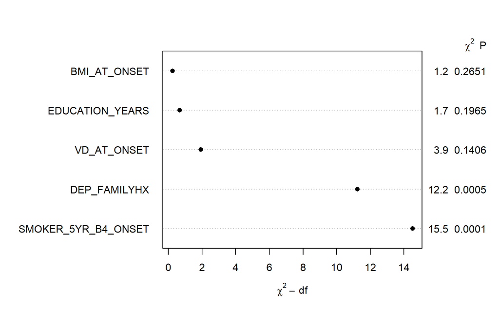

```r
plot(anova(fmi.m.3))
```

Frances Wang

2018-03-08 01:28:25